# FILTERING MOBILE PHONE SPAM USING NAIVE BAYES

VALINE OKEYO

2023-09-26

# Import Dataset

```r
library(readr)
sms_spam <- read_csv("C:/Users/user/Downloads/sms_spam.csv")
View(sms_spam)
```

#Structure of Dataset

```r
str(sms_spam)
```

```
## spc_tbl_ [5,574 × 2] (S3: spec_tbl_df/tbl_df/tbl/data.frame)
##  $ type: chr [1:5574] "ham" "ham" "spam" "ham" ...
##  $ text: chr [1:5574] "Go until jurong point, crazy.. Available only in bugis n great world la e buffet... Cine there got amore wat..." "Ok lar... Joking wif u oni..." "Free entry in 2 a wkly comp to win FA Cup final tkts 21st May 2005. Text FA to 87121 to receive entry question("| __truncated__ …
##  - attr(*, "spec")=
##   .. cols(
##   ..   type = col_character(),
##   ..   text = col_character()
##   .. )
##  - attr(*, "problems")=<externalptr>
```

# Convert variable “type” to a factor

```r
sms_spam$type <- as.factor(sms_spam$type)
```

```r
str(sms_spam$type)
```

```
##  Factor w/ 2 levels "ham","spam": 1 1 2 1 1 2 1 1 2 2 ...
```

```r
table(sms_spam$type)
```

```
##
##  ham spam
## 4827  747
```

# For Text Data Processing,

```r
library(tm)
```

# To process the text data, we need to create a corpus(collection of text documents)

```r
sms_corpus <- Corpus(VectorSource(sms_spam$text))
print(sms_corpus)
```

```
## <<SimpleCorpus>>
## Metadata:  corpus specific: 1, document level (indexed): 0
## Content:  documents: 5574
```

#To look at the contents of the corpus, e.g with the first three texts;

```r
inspect(sms_corpus[1:3])
```

```
## <<SimpleCorpus>>
## Metadata:  corpus specific: 1, document level (indexed): 0
## Content:  documents: 3
##
## [1] Go until jurong point, crazy.. Available only in bugis n great world la e buffet... Cine there got amore wat...
## [2] Ok lar... Joking wif u oni...
## [3] Free entry in 2 a wkly comp to win FA Cup final tkts 21st May 2005. Text FA to 87121 to receive entry question(std txt rate)T&C's apply 08452810075over18's
```

# Convert all of the SMS messages to lowercase and remove any numbers

```r
corpus_clean <- tm_map(sms_corpus,tolower)
corpus_clean <- tm_map(corpus_clean,removeNumbers)
```

#Remove filler words such as “to”, “and”, “but”, and “or”

```r
corpus_clean <- tm_map(corpus_clean, removeWords, stopwords())
```

# We’ll also remove punctuation

```r
corpus_clean <- tm_map(corpus_clean, removePunctuation)
```

# Remove additional whitespace, leaving only a single space between words

```r
corpus_clean <- tm_map(corpus_clean,stripWhitespace)
inspect(corpus_clean[1:3])
```

```
## <<SimpleCorpus>>
## Metadata:  corpus specific: 1, document level (indexed): 0
## Content:  documents: 3
##
## [1] go jurong point crazy available bugis n great world la e buffet cine got amore wat
## [2] ok lar joking wif u oni
## [3] free entry wkly comp win fa cup final tkts st may text fa receive entry questionstd txt ratetcs apply s
```

# Now split the messages into individual components through a process called tokenization

```r
sms_dtm <- DocumentTermMatrix(corpus_clean)
```

# Creating Training and Test Datasets

# We’ll begin by splitting the raw data frame

```r
sms_spam_train <- sms_spam[1:4181,]
sms_spam_test <- sms_spam[4182:5574,]
```

#Then the document-term matrix

```r
sms_dtm_train <- sms_dtm[1:4181,]
sms_dtm_test <- sms_dtm[4182:5574,]
```

#And finally the Corpus

```r
sms_corpus_train <- corpus_clean[1:4181]
sms_corpus_test <- corpus_clean[4182:5574]
```

# To confirm that the subsets are representative of the complete set of SMS data,

```r
prop.table(table(sms_spam_train$type))
```

```
##
##       ham      spam
## 0.8648649 0.1351351
```

```r
prop.table(table(sms_spam_test$type))
```

```
##
##       ham      spam
## 0.8693467 0.1306533
```

- Both the training data and test data contain about 13 percent spam. This suggests that the spam messages were divided evenly between the two datasets.

# Visualizing text data- Word Clouds`

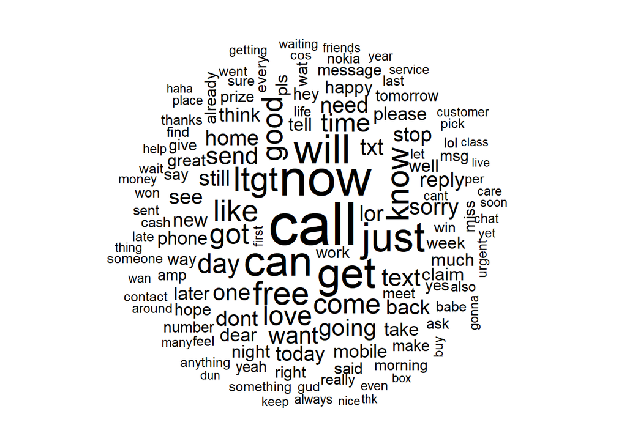

```r
library(wordcloud)
wordcloud(sms_corpus_train, min.freq = 40, random.order = FALSE)
```

# Alternatively:

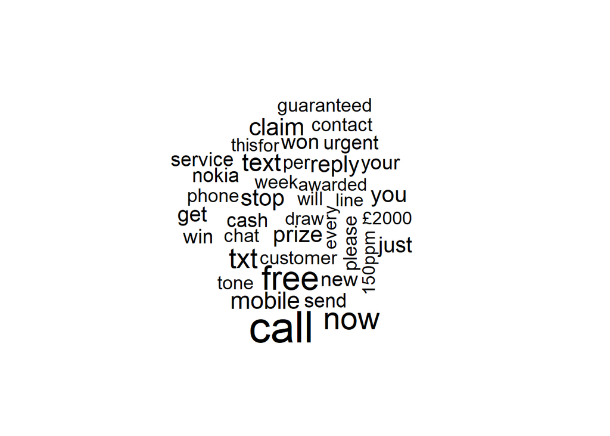

```r
spam <- subset(sms_spam_train,type=="spam")
ham <- subset(sms_spam_train,type=="ham")
wordcloud(spam$text, max.words = 40, scale = c(3,1))
```

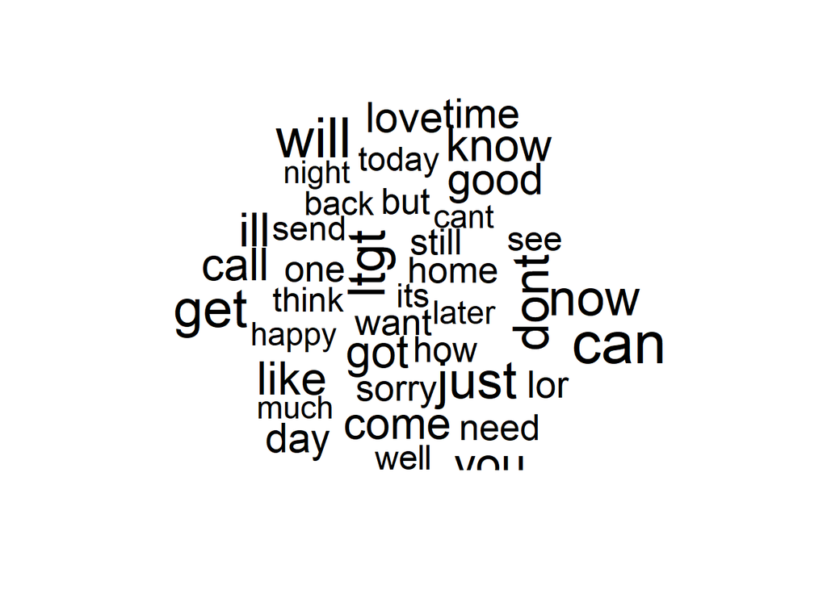

```r
wordcloud(ham$text,max.words = 40,scale = c(3,1))
```

# Creating Indicator features for frequent words

# display a character vector of the words appearing at least 5times in the sms_dtm_train matrix

```r
library(tm)
frequent_terms <- findFreqTerms(sms_dtm_train,5) #character vectors that appear at least 5 times in sms_dtm_train matrix
str(frequent_terms)
```

```
##  chr [1:1231] "available" "bugis" "cine" "crazy" "got" "great" "point" ...
```

```r
term_list <- as.list(frequent_terms)
```

##To save this list of frequent terms for later use,

```r
library(quanteda)
sms_dict <- dictionary(list(terms = findFreqTerms(sms_dtm_train, 5)))
```

#To limit our training and test matrixes to only the words in the preceding dictionary;

```r
sms_train <- DocumentTermMatrix(sms_corpus_train,dictionary(sms_dict))


sms_test <- DocumentTermMatrix(sms_corpus_test,dictionary(sms_dict))
```

```r
convert_counts <- function(x) {
 x <- ifelse(x > 0, 1, 0)
 x <- factor(x, levels = c(0, 1), labels = c("No", "Yes"))
 return(x)
 }
```

```r
sms_train <- apply(sms_train, MARGIN = 2, convert_counts)

sms_test <- apply(sms_test, MARGIN = 2, convert_counts)
```

```r
library(e1071)
sms_classifier <- naiveBayes(sms_train, sms_spam_train$type)
```

```r
sms_test_pred <- predict(sms_classifier,sms_test)
```

```r
library(gmodels)

CrossTable(sms_test_pred, sms_spam_test$type,
 prop.chisq = TRUE, prop.t = FALSE,
 dnn = c('predicted', 'actual'))
```

```
##
##
##    Cell Contents
## |-------------------------|
## |                       N |
## | Chi-square contribution |
## |           N / Row Total |
## |           N / Col Total |
## |-------------------------|
##
##
## Total Observations in Table:  1393
##
##
##              | actual
##    predicted |       ham |      spam | Row Total |
## -------------|-----------|-----------|-----------|
##          ham |      1199 |        16 |      1215 |
##              |    19.291 |   128.356 |           |
##              |     0.987 |     0.013 |     0.872 |
##              |     0.990 |     0.088 |           |
## -------------|-----------|-----------|-----------|
##         spam |        12 |       166 |       178 |
##              |   131.674 |   876.140 |           |
##              |     0.067 |     0.933 |     0.128 |
##              |     0.010 |     0.912 |           |
## -------------|-----------|-----------|-----------|
## Column Total |      1211 |       182 |      1393 |
##              |     0.869 |     0.131 |           |
## -------------|-----------|-----------|-----------|
##
##
```

- We can see that 12 out of 1211 ham messages were incorrectly classified as spam while 16 out 182 spam messages were incorrectly classified as ham. Considering the little effort we put into the project, this level of performance seems quite impressive.